# Final Project Report

# Final logistic model

Removing smoke variable as it is the most insignificant variable with p-value equal to 0.1441 (Significance level = 0.05)

```r
fit_all11 <- glm(low_bwt ~ len_preg+marital, family = binomial(), data = births)
summary(fit_all11)
```

[output not shown]

```r
pR2(fit_all11)
```

```
##          llh      llhNull           G2     McFadden         r2ML         r2CU
## -198.0396885 -348.6009843  301.1225915    0.4319015    0.2604594    0.5181017
```

```r
exp(cbind(OR=coef(fit_all11), confint(fit_all11)))
```

```
##                            OR        2.5 %       97.5 %
## (Intercept)      1.845089e+10 2.798761e+08 1.854117e+12
## len_preg         4.951682e-01 4.363693e-01 5.551420e-01
## maritalunmarried 1.952728e+00 1.149141e+00 3.333546e+00
```

```r
exp(coef(fit_all11))
```

```
##      (Intercept)         len_preg maritalunmarried
##     1.845089e+10     4.951682e-01     1.952728e+00
```

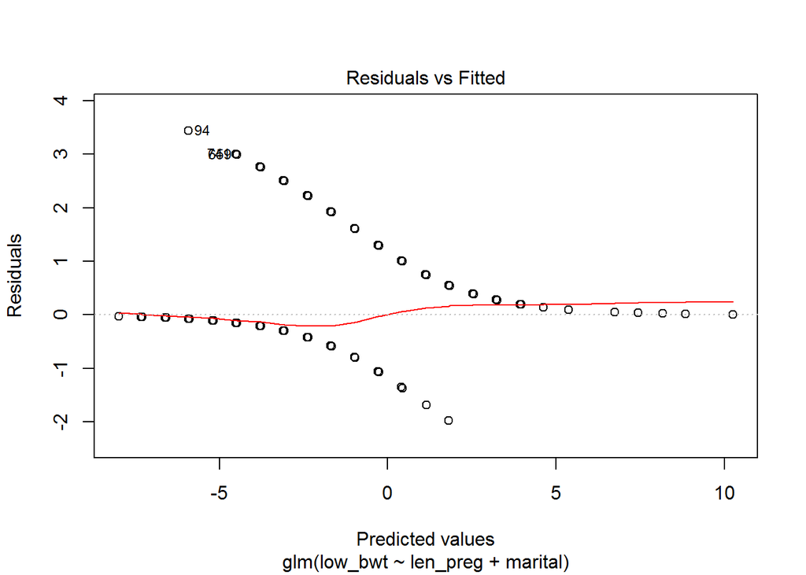

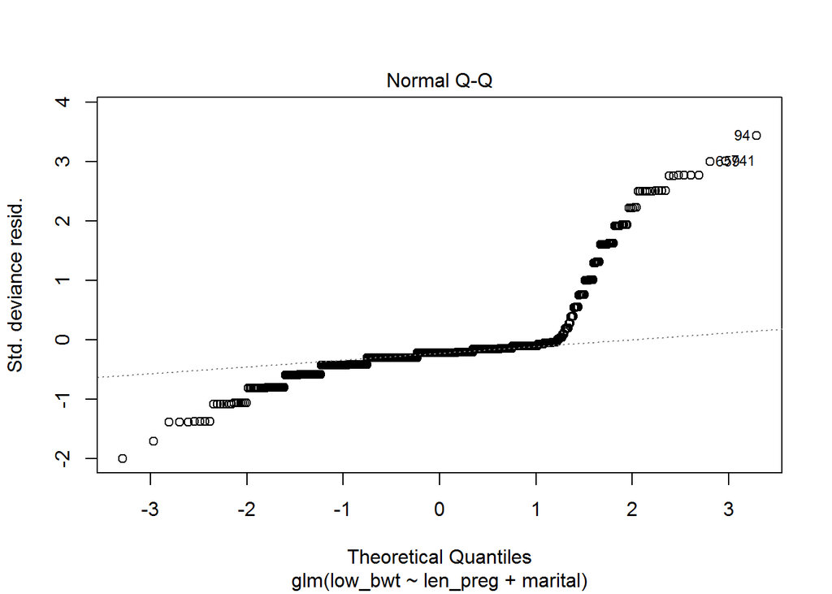

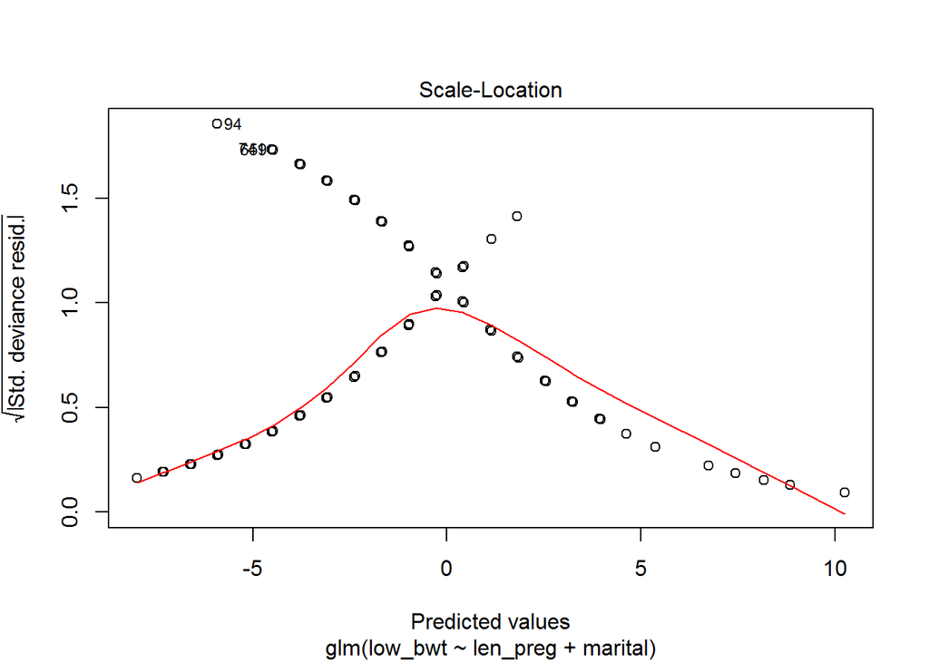

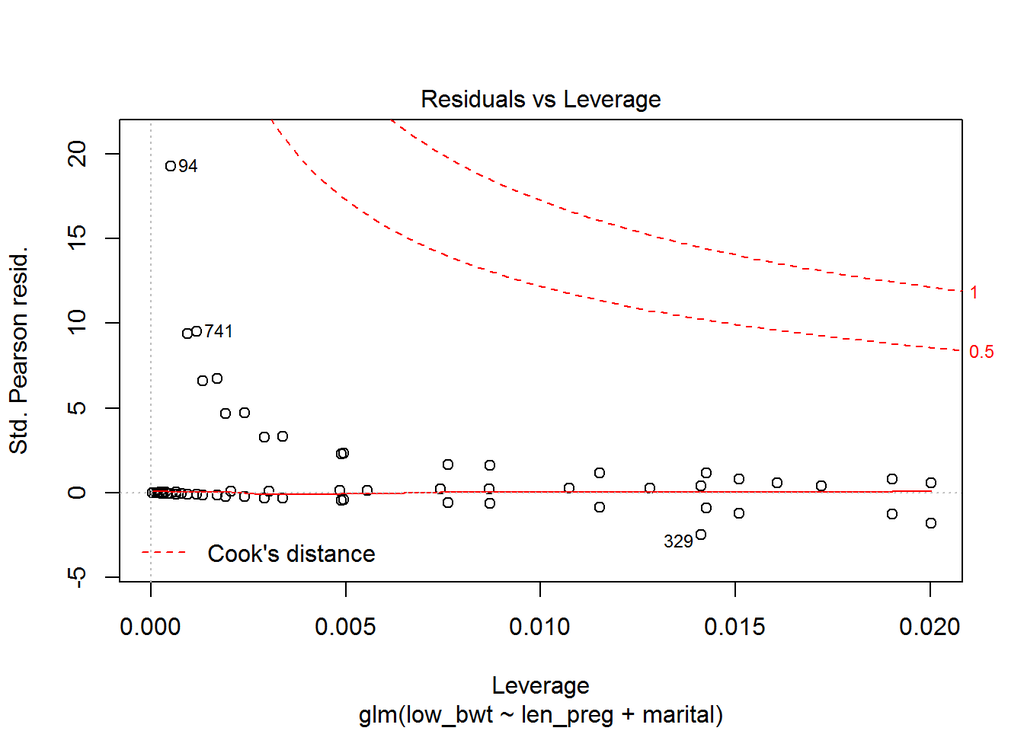

```r
plot(fit_all11)
```

McFadden: 0.4319015  
r2CU: 0.5181017

# Equation for fitted coefficients:

logit(low_bwt) = -0.70286 * (len_preg) + 0.66923 * (maritalunmarried) + 23.63838

# Effect of significant variables on low_bwt variable:

For umarried mother at time of birth as compared with married mother at time of birth, the odds of having baby with low birthweight (pounds) is multiplied by exp(0.66923)=1.952728 (ie: an increase of 95%) on average when all other variables in the model are held constant.

# Using step function to check AIC and if we get the same significant variables as my final logistics model:

Creating new dataframe without dad_age column as it has lots of missing information:

```r
birth_2 <- births[,2:14]
birth_2 <- na.omit(birth_2)
summary(birth_2)
```

```
##     mom_age          maturity      len_preg       is_premie     num_visits
##  Min.   :13.00   younger :835   Min.   :20.0   fullterm:819   Min.   : 0.0
##  1st Qu.:22.00   advanced:127   1st Qu.:37.0   premie  :143   1st Qu.:10.0
##  Median :27.00                  Median :39.0                  Median :12.0
##  Mean   :27.01                  Mean   :38.4                  Mean   :12.2
##  3rd Qu.:32.00                  3rd Qu.:40.0                  3rd Qu.:15.0
##  Max.   :50.00                  Max.   :45.0                  Max.   :30.0
##       marital     mom_wt_gain         bwt           low_bwt        sex
##  married  :599   Min.   : 0.00   Min.   : 1.000   notlow:860   female:483
##  unmarried:363   1st Qu.:20.00   1st Qu.: 6.380   low   :102   male  :479
##                  Median :30.00   Median : 7.310
##                  Mean   :30.34   Mean   : 7.128
##                  3rd Qu.:38.00   3rd Qu.: 8.060
##                  Max.   :85.00   Max.   :11.750
##        smoke        mom_white    mom_age_level
##  nonsmoker:841   nonwhite:272   teens   :103
##  smoker   :121   white   :690   early20s:269
##                                 late20s :250
##                                 early30s:213
##                                 35+     :127
##
```

```r
fit_null <- glm(low_bwt ~ 1, family = binomial(), data = birth_2)
summary(fit_null)
```

```
##
## Call:
## glm(formula = low_bwt ~ 1, family = binomial(), data = birth_2)
##
## Deviance Residuals:
##     Min       1Q   Median       3Q      Max
## -0.4735  -0.4735  -0.4735  -0.4735   2.1185
##
## Coefficients:
##             Estimate Std. Error z value Pr(>|z|)
## (Intercept)  -2.1320     0.1047  -20.36   <2e-16 ***
## ---
## Signif. codes:  0 '***' 0.001 '**' 0.01 '*' 0.05 '.' 0.1 ' ' 1
##
## (Dispersion parameter for binomial family taken to be 1)
##
##     Null deviance: 650.57  on 961  degrees of freedom
## Residual deviance: 650.57  on 961  degrees of freedom
## AIC: 652.57
##
## Number of Fisher Scoring iterations: 4
```

Removing mom_age_level variable, since it is a dichotomised version of mom_age and has a very high positive correlation as shown (0.9740499)  
Removing bwt variable as it has high negative correlation with low_bwt variable (-0.5441694) and low_bwt variable is dichotomised version of bwt variable

```r
fit_main <- glm(low_bwt ~ mom_age+len_preg+num_visits+mom_wt_gain+maturity+is_premie+smoke+marital+mom_white+sex, family = binomial(), data = birth_2)
summary(fit_main)
```

```
##
## Call:
## glm(formula = low_bwt ~ mom_age + len_preg + num_visits + mom_wt_gain +
##     maturity + is_premie + smoke + marital + mom_white + sex,
##     family = binomial(), data = birth_2)
##
## Deviance Residuals:
##     Min       1Q   Median       3Q      Max
## -1.8322  -0.3232  -0.2171  -0.1328   3.4597
##
## Coefficients:
##                   Estimate Std. Error z value Pr(>|z|)
## (Intercept)      21.013120   4.152910   5.060  4.2e-07 ***
## mom_age          -0.002514   0.032108  -0.078   0.9376
## len_preg         -0.638696   0.105039  -6.081  1.2e-09 ***
## num_visits        0.040347   0.032789   1.230   0.2185
## mom_wt_gain      -0.012158   0.010494  -1.159   0.2466
## maturityadvanced  0.275132   0.543351   0.506   0.6126
## is_premiepremie   0.340374   0.481983   0.706   0.4801
## smokesmoker       0.698477   0.365566   1.911   0.0560 .
## maritalunmarried  0.729563   0.325191   2.243   0.0249 *
## mom_whitewhite    0.034356   0.318194   0.108   0.9140
## sexmale          -0.299270   0.283064  -1.057   0.2904
## ---
## Signif. codes:  0 '***' 0.001 '**' 0.01 '*' 0.05 '.' 0.1 ' ' 1
##
## (Dispersion parameter for binomial family taken to be 1)
##
##     Null deviance: 650.57  on 961  degrees of freedom
## Residual deviance: 376.60  on 951  degrees of freedom
## AIC: 398.6
##
## Number of Fisher Scoring iterations: 6
```

```r
fit_step1 <- step(fit_null, scope=list(lower=fit_null, upper=fit_main),direction="both")
```

```
## Start:  AIC=652.57
## low_bwt ~ 1
##
##               Df Deviance    AIC
## + len_preg     1   390.59 394.59
## + is_premie    1   455.53 459.53
## + marital      1   636.71 640.71
## + num_visits   1   640.42 644.42
## + mom_wt_gain  1   640.42 644.42
## + mom_white    1   646.24 650.24
## + smoke        1   648.12 652.12
## <none>             650.57 652.57
## + maturity     1   649.44 653.44
## + sex          1   650.22 654.22
## + mom_age      1   650.56 654.56
##
## Step:  AIC=394.59
## low_bwt ~ len_preg
##
##               Df Deviance    AIC
## + marital      1   384.26 390.26
## + smoke        1   387.41 393.41
## <none>             390.59 394.59
## + mom_wt_gain  1   388.72 394.72
## + sex          1   389.71 395.71
## + is_premie    1   389.91 395.91
## + mom_white    1   390.11 396.11
## + mom_age      1   390.34 396.34
## + num_visits   1   390.37 396.37
## + maturity     1   390.46 396.46
## - len_preg     1   650.57 652.57
##
## Step:  AIC=390.26
## low_bwt ~ len_preg + marital
##
##               Df Deviance    AIC
## + smoke        1   381.67 389.67
## <none>             384.26 390.26
## + mom_wt_gain  1   383.00 391.00
## + num_visits   1   383.00 391.00
```

[output cut: 8 more lines]

```
## Step:  AIC=389.67
## low_bwt ~ len_preg + marital + smoke
##
##               Df Deviance    AIC
## <none>             381.67 389.67
## + num_visits   1   380.09 390.09
## - smoke        1   384.26 390.26
## + mom_wt_gain  1   380.30 390.30
## + sex          1   380.56 390.56
## + is_premie    1   381.05 391.05
## + maturity     1   381.12 391.12
## + mom_age      1   381.33 391.33
## + mom_white    1   381.67 391.67
## - marital      1   387.41 393.41
## - len_preg     1   635.35 641.35
```

```r
summary(fit_step1)
```

```
##
## Call:
## glm(formula = low_bwt ~ len_preg + marital + smoke, family = binomial(),
##     data = birth_2)
##
## Deviance Residuals:
##     Min       1Q   Median       3Q      Max
## -1.9055  -0.2905  -0.2072  -0.1457   3.4396
##
## Coefficients:
##                  Estimate Std. Error z value Pr(>|z|)
## (Intercept)      22.94011    2.24980  10.196   <2e-16 ***
## len_preg         -0.68642    0.06158 -11.146   <2e-16 ***
## maritalunmarried  0.66335    0.27683   2.396   0.0166 *
## smokesmoker       0.59549    0.35969   1.656   0.0978 .
## ---
## Signif. codes:  0 '***' 0.001 '**' 0.01 '*' 0.05 '.' 0.1 ' ' 1
##
## (Dispersion parameter for binomial family taken to be 1)
##
##     Null deviance: 650.57  on 961  degrees of freedom
## Residual deviance: 381.67  on 958  degrees of freedom
## AIC: 389.67
##
## Number of Fisher Scoring iterations: 6
```

# Comment:

Even if we keep mom_age_level variable as the predictor variable for step function, we would still be getting the same results (AIC, significant variables) as we got without mom_age_level variable. This result of the step function is found to be consistent with my final logistic model (with same significant variables and similar fitted coefficients) except for the smoke variable which is not a significant variable in my final model as its p-value is greater than significance level of 0.05